# Communicate Data Analysis:Ford GoBike TourData For February 2019

## by (Ajogi Paul Iye)

## Investigation Overview

In this examination, I sought to look at the interplay of group of users that mostly useed the services of Ford Gobike. The major features that caught my attention are the qualitative variables listed below:

#### . age category

#### . member gender

#### . user type

## Dataset Overview

The dataset explored comprises 183412 observations and 16 columns before cleaning.After proper cleaning, tiding due to data inconsistency and missing information, it became 174952 cases and 18 columns respectively. The most paramount characteristics are qualitative variable as ealier mentioned and other interesting measurement which are but not limited to:

#### . bike_ids

#### . bike_shape_for_all_trip

#### . start_station_latitude

#### . end_station_latitude

#### . start_station_longitude

#### . end_station_longitude

#### . start_station_name

#### . end_station_name

```python
# import all packages and set plots to be embedded inline
import numpy as np
import pandas as pd
import matplotlib.pyplot as plt
import seaborn as sb

%matplotlib inline

import warnings
warnings.filterwarnings('ignore')
```

```python
# load in the dataset into pandas dataframe
fordgo_bike = pd.read_csv('fordgobike-tripdata-201902.csv')
```

```python
# display original dataset information
fordgo_bike.info()
```

```
<class 'pandas.core.frame.DataFrame'>
RangeIndex: 183412 entries, 0 to 183411
Data columns (total 16 columns):
 #   Column                   Non-Null Count   Dtype
---  ------                   --------------   -----
 0   duration_sec             183412 non-null  int64
 1   start_time               183412 non-null  object
 2   end_time                 183412 non-null  object
 3   start_station_id         183215 non-null  float64
 4   start_station_name       183215 non-null  object
 5   start_station_latitude   183412 non-null  float64
 6   start_station_longitude  183412 non-null  float64
 7   end_station_id           183215 non-null  float64
 8   end_station_name         183215 non-null  object
 9   end_station_latitude     183412 non-null  float64
 10  end_station_longitude    183412 non-null  float64
 11  bike_id                  183412 non-null  int64
 12  user_type                183412 non-null  object
 13  member_birth_year        175147 non-null  float64
 14  member_gender            175147 non-null  object
 15  bike_share_for_all_trip  183412 non-null  object
dtypes: float64(7), int64(2), object(7)
memory usage: 22.4+ MB
```

## Assessment

Assessing visually </br>

```python
fordgo_bike.shape
```

```
(183412, 16)
```

```python
fordgo_bike.head(15)
```

|  | duration_sec | start_time | end_time | start_station_id | start_station_name | start_station_latitude | start_station_longitude | end_station_id | end_station_name | end_station_latitude | end_station_longitude | bike_id | user_type | member_birth_year | member_gender | bike_share_for_all_trip |
| --- | --- | --- | --- | --- | --- | --- | --- | --- | --- | --- | --- | --- | --- | --- | --- | --- |
| 0 | 52185 | 2019-02-28 17:32:10.1450 | 2019-03-01 08:01:55.9750 | 21.0 | Montgomery St BART Station (Market St at 2nd St) | 37.789625 | -122.400811 | 13.0 | Commercial St at Montgomery St | 37.794231 | -122.402923 | 4902 | Customer | 1984.0 | Male | No |
| 1 | 42521 | 2019-02-28 18:53:21.7890 | 2019-03-01 06:42:03.0560 | 23.0 | The Embarcadero at Steuart St | 37.791464 | -122.391034 | 81.0 | Berry St at 4th St | 37.775880 | -122.393170 | 2535 | Customer | NaN | NaN | No |
| 2 | 61854 | 2019-02-28 12:13:13.2180 | 2019-03-01 05:24:08.1460 | 86.0 | Market St at Dolores St | 37.769305 | -122.426826 | 3.0 | Powell St BART Station (Market St at 4th St) | 37.786375 | -122.404904 | 5905 | Customer | 1972.0 | Male | No |
| 3 | 36490 | 2019-02-28 17:54:26.0100 | 2019-03-01 04:02:36.8420 | 375.0 | Grove St at Masonic Ave | 37.774836 | -122.446546 | 70.0 | Central Ave at Fell St | 37.773311 | -122.444293 | 6638 | Subscriber | 1989.0 | Other | No |
| 4 | 1585 | 2019-02-28 23:54:18.5490 | 2019-03-01 00:20:44.0740 | 7.0 | Frank H Ogawa Plaza | 37.804562 | -122.271738 | 222.0 | 10th Ave at E 15th St | 37.792714 | -122.248780 | 4898 | Subscriber | 1974.0 | Male | Yes |
| 5 | 1793 | 2019-02-28 23:49:58.6320 | 2019-03-01 00:19:51.7600 | 93.0 | 4th St at Mission Bay Blvd S | 37.770407 | -122.391198 | 323.0 | Broadway at Kearny | 37.798014 | -122.405950 | 5200 | Subscriber | 1959.0 | Male | No |
| 6 | 1147 | 2019-02-28 23:55:35.1040 | 2019-03-01 00:14:42.5880 | 300.0 | Palm St at Willow St | 37.317298 | -121.884995 | 312.0 | San Jose Diridon Station | 37.329732 | -121.901782 | 3803 | Subscriber | 1983.0 | Female | No |
| 7 | 1615 | 2019-02-28 23:41:06.7660 | 2019-03-01 00:08:02.7560 | 10.0 | Washington St at Kearny St | 37.795393 | -122.404770 | 127.0 | Valencia St at 21st St | 37.756708 | -122.421025 | 6329 | Subscriber | 1989.0 | Male | No |
| 8 | 1570 | 2019-02-28 23:41:48.7900 | 2019-03-01 00:07:59.7150 | 10.0 | Washington St at Kearny St | 37.795393 | -122.404770 | 127.0 | Valencia St at 21st St | 37.756708 | -122.421025 | 6548 | Subscriber | 1988.0 | Other | No |
| 9 | 1049 | 2019-02-28 23:49:47.6990 | 2019-03-01 00:07:17.0250 | 19.0 | Post St at Kearny St | 37.788975 | -122.403452 | 121.0 | Mission Playground | 37.759210 | -122.421339 | 6488 | Subscriber | 1992.0 | Male | No |
| 10 | 458 | 2019-02-28 23:57:57.2110 | 2019-03-01 00:05:35.4350 | 370.0 | Jones St at Post St | 37.787327 | -122.413278 | 43.0 | San Francisco Public Library (Grove St at Hyde... | 37.778768 | -122.415929 | 5318 | Subscriber | 1996.0 | Female | Yes |
| 11 | 506 | 2019-02-28 23:56:55.5400 | 2019-03-01 00:05:21.7330 | 44.0 | Civic Center/UN Plaza BART Station (Market St ... | 37.781074 | -122.411738 | 343.0 | Bryant St at 2nd St | 37.783172 | -122.393572 | 5848 | Subscriber | 1993.0 | Male | No |
| 12 | 1176 | 2019-02-28 23:45:12.6510 | 2019-03-01 00:04:49.1840 | 127.0 | Valencia St at 21st St | 37.756708 | -122.421025 | 323.0 | Broadway at Kearny | 37.798014 | -122.405950 | 5328 | Customer | 1990.0 | Male | No |
| 13 | 915 | 2019-02-28 23:49:06.0620 | 2019-03-01 00:04:21.8670 | 252.0 | Channing Way at Shattuck Ave | 37.865847 | -122.267443 | 244.0 | Shattuck Ave at Hearst Ave | 37.873676 | -122.268487 | 5101 | Subscriber | NaN | NaN | No |
| 14 | 395 | 2019-02-28 23:56:26.8480 | 2019-03-01 00:03:01.9470 | 243.0 | Bancroft Way at College Ave | 37.869360 | -122.254337 | 252.0 | Channing Way at Shattuck Ave | 37.865847 | -122.267443 | 4786 | Subscriber | 1988.0 | Male | No |

```python
fordgo_bike.info()
```

```
<class 'pandas.core.frame.DataFrame'>
RangeIndex: 183412 entries, 0 to 183411
Data columns (total 16 columns):
 #   Column                   Non-Null Count   Dtype
---  ------                   --------------   -----
 0   duration_sec             183412 non-null  int64
 1   start_time               183412 non-null  object
 2   end_time                 183412 non-null  object
 3   start_station_id         183215 non-null  float64
 4   start_station_name       183215 non-null  object
 5   start_station_latitude   183412 non-null  float64
 6   start_station_longitude  183412 non-null  float64
 7   end_station_id           183215 non-null  float64
 8   end_station_name         183215 non-null  object
 9   end_station_latitude     183412 non-null  float64
 10  end_station_longitude    183412 non-null  float64
 11  bike_id                  183412 non-null  int64
 12  user_type                183412 non-null  object
 13  member_birth_year        175147 non-null  float64
 14  member_gender            175147 non-null  object
 15  bike_share_for_all_trip  183412 non-null  object
dtypes: float64(7), int64(2), object(7)
memory usage: 22.4+ MB
```

```python
fordgo_bike.isnull().sum()
```

```
duration_sec                  0
start_time                    0
end_time                      0
start_station_id            197
start_station_name          197
start_station_latitude        0
start_station_longitude       0
end_station_id              197
end_station_name            197
end_station_latitude          0
end_station_longitude         0
bike_id                       0
user_type                     0
member_birth_year          8265
member_gender              8265
bike_share_for_all_trip       0
dtype: int64
```

```python
fordgo_bike.duplicated().sum()
```

```
0
```

## Data Assessing and Cleaning

#### 1 .Drop null values in start_station_id,start_station_name,end_station_id,end_station_name,member_birth_year,member_gender

#### 2 .Convert Datatype of member_birth_year from float to int

#### 3 .Change start_time and end_time from object to datetime

#### 4 .Change to categorical variable user_type,member_gender,bike_share_share_for_all_trip

#### 5 .Create new column for day of the week and time of the day

#### 6 .Convert Datatype of duration_sec from integer to minutes

#### 7 .Convert member_birth_year to user year

```python
df_fordgobike = fordgo_bike.copy()
```

```python
# drop null values in 1 above
df_fordgobike.dropna(inplace=True)
```

```python
# test for null
df_fordgobike.isnull().sum()
```

```
duration_sec               0
start_time                 0
end_time                   0
start_station_id           0
start_station_name         0
start_station_latitude     0
start_station_longitude    0
end_station_id             0
end_station_name           0
end_station_latitude       0
end_station_longitude      0
bike_id                    0
user_type                  0
member_birth_year          0
member_gender              0
bike_share_for_all_trip    0
dtype: int64
```

```python
# generate function to test Dtype
def test_type(x):
    for var in x:
        print(f'{var} ----> {df_fordgobike[var].dtype}')
```

```python
# convert usertype,member_gender,bike_share_for_all_trip to categorical type
cass =['user_type', 'member_gender', 'bike_share_for_all_trip']
for var in cass:
    df_fordgobike[var]=df_fordgobike[var].astype('category')
```

```python
# conversion test
test_type(cass)
```

```
user_type ----> category
member_gender ----> category
bike_share_for_all_trip ----> category
```

```python
# convert to datetime format start_time and end_time
cass =['start_time', 'end_time']
for var in cass:
    df_fordgobike[var]=pd.to_datetime(df_fordgobike[var])
```

```python
# test convertion
test_type(cass)
```

```
start_time ----> datetime64[ns]
end_time ----> datetime64[ns]
```

```python
# change birth year to integer
df_fordgobike.member_birth_year=df_fordgobike.member_birth_year.astype('int')
```

```python
# remove and save in new column am and pm
df_fordgobike['time_of_day']=pd.to_datetime(df_fordgobike.start_time).dt.strftime('%p')
```

```python
# test column
df_fordgobike.time_of_day
```

```
0         PM
2         PM
3         PM
4         PM
5         PM
          ..
183407    AM
183408    AM
183409    AM
183410    AM
183411    AM
Name: time_of_day, Length: 174952, dtype: object
```

```python
# remove day of the week to 'day_of_week' column
df_fordgobike['day_of_week']=pd.to_datetime(df_fordgobike.start_time).dt.strftime('%A')
```

```python
# test column
df_fordgobike.day_of_week
```

```
0         Thursday
2         Thursday
3         Thursday
4         Thursday
5         Thursday
            ...
183407      Friday
183408      Friday
183409      Friday
183410      Friday
183411      Friday
Name: day_of_week, Length: 174952, dtype: object
```

```python
# rename duration_sec to duration_min
def renameColumn(old_name,new_name):
    df_fordgobike.rename(columns={old_name:new_name},inplace=True)
# convert column name
renameColumn('duration_sec','duration_min')
df_fordgobike.duration_min=df_fordgobike.duration_min/60
```

```python
# test convertion
df_fordgobike.duration_min
```

```
0          869.750000
2         1030.900000
3          608.166667
4           26.416667
5           29.883333
             ...
183407       8.000000
183408       5.216667
183409       2.350000
183410       2.316667
183411       4.516667
Name: duration_min, Length: 174952, dtype: float64
```

```python
# retitle member_birth_year to user_age
renameColumn('member_birth_year','user_age')
# change birth_year to age
df_fordgobike.user_age=df_fordgobike.start_time.dt.year - df_fordgobike.user_age
```

## Further Data Analysis

```python
# display information about clean dataset
df_fordgobike.info()
```

```
<class 'pandas.core.frame.DataFrame'>
Int64Index: 174952 entries, 0 to 183411
Data columns (total 18 columns):
 #   Column                   Non-Null Count   Dtype
---  ------                   --------------   -----
 0   duration_min             174952 non-null  float64
 1   start_time               174952 non-null  datetime64[ns]
 2   end_time                 174952 non-null  datetime64[ns]
 3   start_station_id         174952 non-null  float64
 4   start_station_name       174952 non-null  object
 5   start_station_latitude   174952 non-null  float64
 6   start_station_longitude  174952 non-null  float64
 7   end_station_id           174952 non-null  float64
 8   end_station_name         174952 non-null  object
 9   end_station_latitude     174952 non-null  float64
 10  end_station_longitude    174952 non-null  float64
 11  bike_id                  174952 non-null  int64
 12  user_type                174952 non-null  category
 13  user_age                 174952 non-null  int64
 14  member_gender            174952 non-null  category
 15  bike_share_for_all_trip  174952 non-null  category
 16  time_of_day              174952 non-null  object
 17  day_of_week              174952 non-null  object
dtypes: category(3), datetime64[ns](2), float64(7), int64(2), object(4)
memory usage: 21.9+ MB
```

```python
df_fordgobike.shape
```

```
(174952, 18)
```

```python
# Numeric variable descriptive statistics
df_fordgobike.describe()
```

|  | duration_min | start_station_id | start_station_latitude | start_station_longitude | end_station_id | end_station_latitude | end_station_longitude | bike_id | user_age |
| --- | --- | --- | --- | --- | --- | --- | --- | --- | --- |
| count | 174952.000000 | 174952.000000 | 174952.000000 | 174952.000000 | 174952.000000 | 174952.000000 | 174952.000000 | 174952.000000 | 174952.000000 |
| mean | 11.733379 | 139.002126 | 37.771220 | -122.351760 | 136.604486 | 37.771414 | -122.351335 | 4482.587555 | 34.196865 |
| std | 27.370082 | 111.648819 | 0.100391 | 0.117732 | 111.335635 | 0.100295 | 0.117294 | 1659.195937 | 10.118731 |
| min | 1.016667 | 3.000000 | 37.317298 | -122.453704 | 3.000000 | 37.317298 | -122.453704 | 11.000000 | 18.000000 |
| 25% | 5.383333 | 47.000000 | 37.770407 | -122.411901 | 44.000000 | 37.770407 | -122.411647 | 3799.000000 | 27.000000 |
| 50% | 8.500000 | 104.000000 | 37.780760 | -122.398279 | 101.000000 | 37.781010 | -122.397437 | 4960.000000 | 32.000000 |
| 75% | 13.150000 | 239.000000 | 37.797320 | -122.283093 | 238.000000 | 37.797673 | -122.286533 | 5505.000000 | 39.000000 |
| max | 1409.133333 | 398.000000 | 37.880222 | -121.874119 | 398.000000 | 37.880222 | -121.874119 | 6645.000000 | 141.000000 |

## Duration minutes Spreading

1min to around 1000mins is the range for duration minutes and it peaked around 8mins.There emerged a unimodal shape of spreading when plotted on logarithic scale.

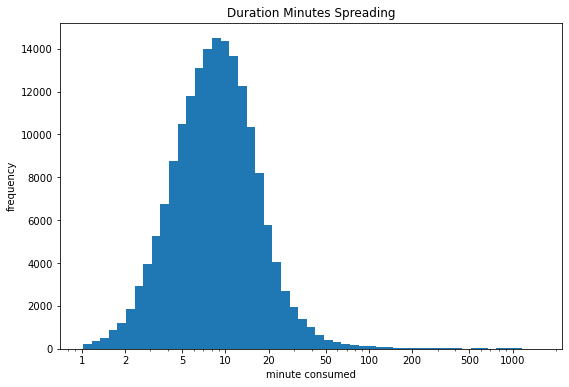

```python
# log scal plotting
def plot_hist(data,size,var,log_plot=False):
    if log_plot:
        plt.figure(figsize=[9,6]);
        bins=10**np.arange(np.log10(data['duration_min'].min()),np.log10(data['duration_min'].max())+size,size)
        plt.hist(data=data,x=var,bins=bins);
        plt.xscale('log');

    else:
        plt.figure(figsize=[9,6]);
        bins=np.arange(data[var].min(),data[var].max()+size,size)
        plt.hist(data=data,x=var,bins=bins);

plot_hist(df_fordgobike,0.06,'duration_min',log_plot=True)
plt.xlabel('minute consumed');
plt.ylabel('frequency');
plt.title('Duration Minutes Spreading');
xloc=[1,2,5,10,20,50,100,200,500,1000]
xlabel=['{}'.format(v) for v in xloc]
plt.xticks(xloc,xlabel);
```

## Categorical Variables Total Count Spreading

Count spreading presents the categories that are greater in number

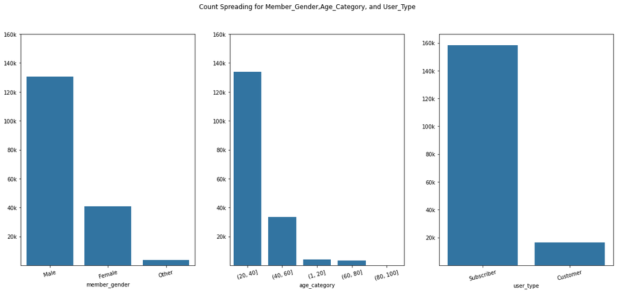

```python
# generate age_category column for explicit spreading
df_fordgobike['age_category'] = pd.cut(x=df_fordgobike['user_age'], bins=[1, 20, 40, 60, 80, 100])
yloc=[20000,40000,60000,80000,100000,120000,140000,160000]
ylabel=['20k','40k','60k','80k','100k','120k','140k','160k']
# graph plotting
plot_title='Count Spreading for Member_Gender,Age_Category, and User_Type'

def plot_count(data,variables,title):
    fig, ax = plt.subplots(ncols=2, nrows=1, figsize=[20,8])
    fig.suptitle(title);
    color=sb.color_palette()[0]
    if len(variables) < 3:
        order={variables[0]:data[variables[0]].value_counts().index,
               variables[1]:data[variables[1]].value_counts().index,}
    else:
        order={variables[0]:data[variables[0]].value_counts().index,
               variables[1]:data[variables[1]].value_counts().index,
               variables[2]:data[variables[2]].value_counts().index,}
    count=1
    for var in variables:
        plt.subplot(1,3,count)
        sb.countplot(data=data,x=var,color=color,order=order[var]);
        plt.xticks(rotation=15)
        plt.ylabel('');
        plt.yticks(yloc,ylabel);
        count+=1


variables=['member_gender','age_category','user_type']

plot_count(df_fordgobike,variables,plot_title)
```

At this point we are able to draw more insights for which day of the week and time of the day has the most rendevous among the groups. We see thursday taking the lead on day of week with the most rendevous and afternoon to evenings toping time of the day with most engagements

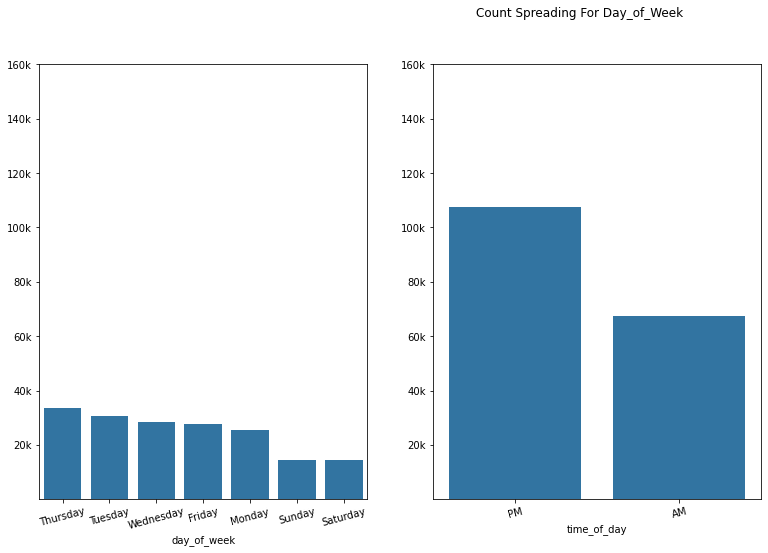

```python
variables = ['day_of_week', 'time_of_day']
plot_title = 'Count Spreading For Day_of_Week'
plot_count(df_fordgobike, variables, plot_title)
```

## Plot of Cycling Duration Verses User_Age

The plot below depicts a great concentration of cycling activity carried out by age range of 20years to around 60years. This implies that this age range is the most active of them all.

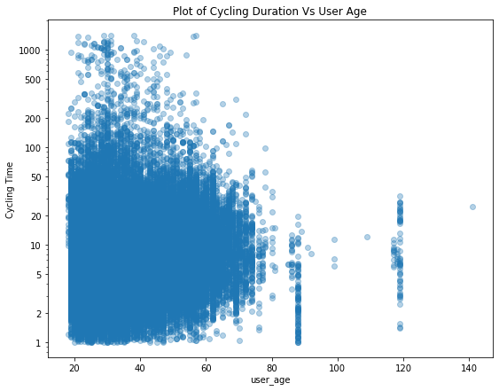

```python
plt.figure(figsize=[9,7])
sb.regplot(data=df_fordgobike,x='user_age',y='duration_min',fit_reg=False,scatter_kws={'alpha':1/3});
plt.yscale('log')
y_loc=[1,2,5,10,20,50,100,200,500,1000]
y_labels=['{}'.format(v) for v in y_loc]
plt.yticks(y_loc,y_labels);
plt.ylabel('Cycling Time');
plt.title('Plot of Cycling Duration Vs User Age');
plt.show();
```

## User_Type,Age_Category,Gender and Time_of_Day Total and Mean Cycling Time

Below are two dissimilar set of plots depicts that the group of age range (20 to 40)years old subscriber Males are greater in number but on average cycling , they spend smaller time.

### Spreading by count

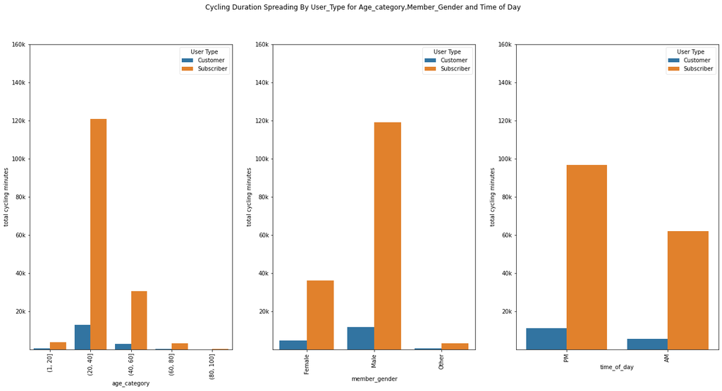

```python
variables = ['age_category','member_gender','time_of_day']
count=1
fig, ax = plt.subplots(ncols=len(variables), figsize=[22,10])
for var in variables:
    plt.subplot(1,3,count)
    sb.countplot(data=df_fordgobike, x=var, hue='user_type');
    plt.xticks(rotation=90)
    plt.ylabel('')
    plt.legend(framealpha=0.5,title='User Type');
    yloc=[20000,40000,60000,80000,100000,120000,140000,160000]
    y_labels=['20k','40k','60k','80k','100k','120k','140k','160k']
    plt.yticks(yloc,y_labels);
    plt.ylabel('total cycling minutes');
    count+=1

fig.suptitle('Cycling Duration Spreading By User_Type for Age_category,Member_Gender and Time of Day');
plt.show();
```

### Spreading by Mean

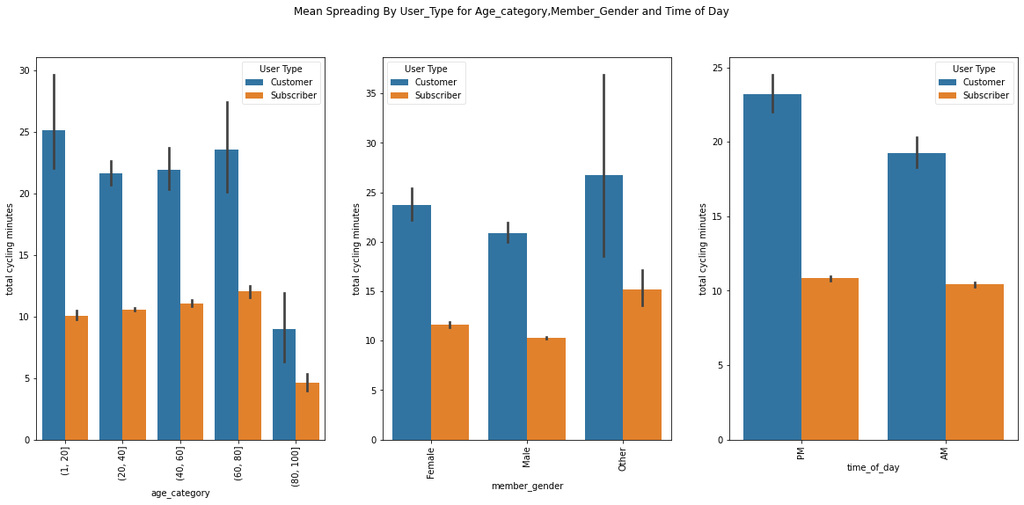

```python
variables = ['age_category','member_gender','time_of_day']
count=1
fig, ax = plt.subplots(ncols=len(variables), figsize=[20,8])
for var in variables:
    plt.subplot(1,3,count)
    sb.barplot(data=df_fordgobike, x=var, y='duration_min', hue='user_type');
    plt.xticks(rotation=90)
    plt.ylabel('')
    plt.legend(framealpha=0.5,title='User Type');
    plt.ylabel('total cycling minutes');
    count+=1
fig.suptitle('Mean Spreading By User_Type for Age_category,Member_Gender and Time of Day');
plt.show();
```

Exploring the trend across all groups

```python
gup_means = df_fordgobike.groupby(['user_type', 'member_gender']).mean()['duration_min']
gup_means = gup_means.reset_index(name = 'duration_min_Avg')
gup_means = gup_means.pivot(index = 'member_gender', columns = 'user_type', values = 'duration_min_Avg')
# sb.heatmap(gup_means, annot =True, fmt = '.3f'
# cbar_kws = {'label': 'mean(num_var2)'})
gup_means

gup_sum = df_fordgobike.groupby(['user_type', 'member_gender']).sum()['duration_min']
gup_sum = gup_sum.reset_index(name = 'duration_min_Avg')
gup_sum = gup_sum.pivot(index = 'member_gender', columns = 'user_type', values = 'duration_min_Avg')
gup_sum
```

| user_type member_gender | Customer | Subscriber |
| --- | --- | --- |
| Female | 109729.066667 | 4.199693e+05 |
| Male | 240125.833333 | 1.222333e+06 |
| Other | 12017.250000 | 4.860370e+04 |

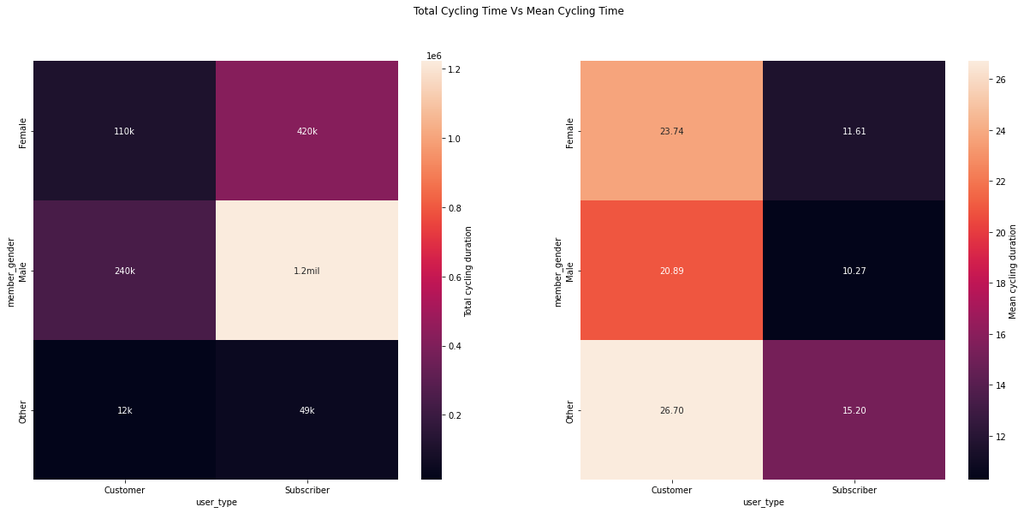

```python
fig, ax = plt.subplots(ncols = 2, figsize = [21,9])
labels = np.array([['110k','420k'], ['240k', '1.2mil'], ['12k', '49k']])
sb.heatmap(gup_sum, annot = labels, fmt = '', ax = ax[0], cbar_kws = {'label':'Total cycling duration'});
sb.heatmap(gup_means, annot = True, fmt = '.2f', ax = ax[1], cbar_kws = {'label':'Mean cycling duration'});
fig.suptitle('Total Cycling Time Vs Mean Cycling Time');
plt.show();
```

### Additional Examination

The plot below depicts numerous range of variables still showing same trend of variables with extra count that has smaller mean cyclying duration. On the avarage customer type though fewer in count spend more time .

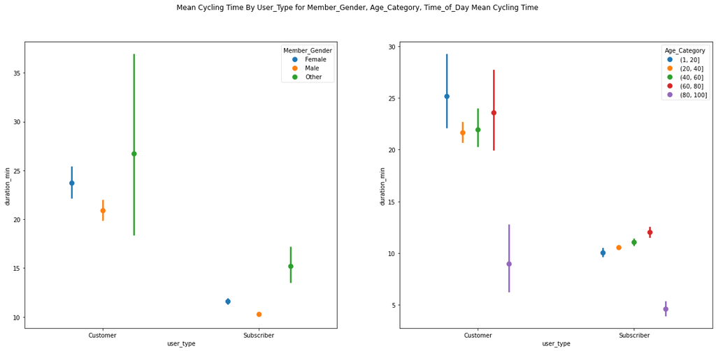

```python
fig, ax = plt.subplots(ncols = 2, figsize = [21,9])

order = df_fordgobike.member_gender.value_counts().index

fig.suptitle('Mean Cycling Time By User_Type for Member_Gender, Age_Category, Time_of_Day Mean Cycling Time');
plt.subplot(1,2,1)
sb.pointplot(data = df_fordgobike, x = 'user_type', y = 'duration_min', hue = 'member_gender', linestyles = '', dodge = 0.4);
plt.legend(framealpha = 0.5, title = 'Member_Gender');
plt.subplot(1,2,2)
sb.pointplot(data = df_fordgobike, x = 'user_type', y = 'duration_min', hue = 'age_category', linestyles = '', dodge = 0.4);
plt.legend(framealpha = 0.5, title = 'Age_Category');
```

### Observed below is Matching Trend

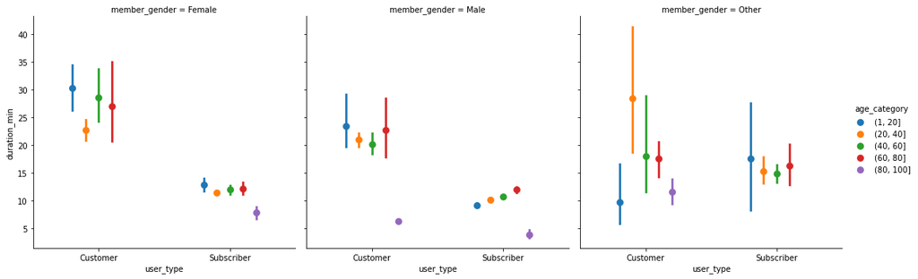

```python
# fig, ax = plt.subplots(ncols = 3, figsize = [21,9])

sb.catplot(data = df_fordgobike, x = 'user_type', y = 'duration_min', hue = 'age_category', kind = 'point', col = 'member_gender', linestyles = '', dodge = 0.4);
plt.show()
```

## Conclusion

The Data Scientist of the Ford-Go-Bike company should alert the top management about this findings.

```python
!jupyter nbconvert Ford_Gobike_System_Data_Part_2.ipynb --to slides --post serve --no-input --no-prompt
```